# Hans Capener - Portfolio

# HELLO! WELCOME TO MY PORTFOLIO!

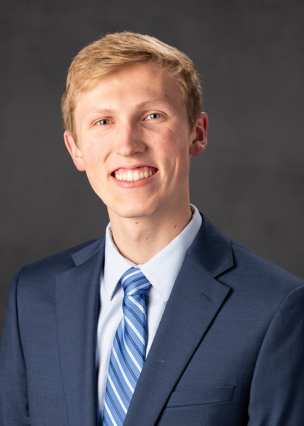

## Hans Capener

**Education:**

- Senior, Data Science major, Brigham Young University-Idaho
- Minoring in Mathematics and Statistics
- Expected Graduation: April 2025

**Future Plans:**

- Intend to pursue a master’s degree in Statistics, considering further studies for a PhD.

# READ ME:

- The purpose of this website to display my capabilities gained from personal projects, as well as school. It has been **designed to navigate quickly to whatever is of most interest** of the viewer by using the side bar on the left.
- **All of the code** used to generate each graph on this website **can be made visible** by clicking the small “Code” button on the right side of the screen above each visualization.
- Some visualizations have **full analyses papers** associated with them; click the links to see them if you are interested. They will by highlighted red like this.

# Skill Showcase

## *USE SIDE BAR* to navigate

## Data Wrangling and Visualization

I am adept with R(tidyverse) and Python(pandas and seaborn) for data wrangling and visualization.

## Statistical Analysis

I can create interpretable multiple linear regression models, as well as perform many other statistical tests.

## SQL

Comfortable querying large databases.

Familiar with database design.

## Machine Learning

Familiar with Neural Networks (including CNN and RNN). Comfortable with XGBoost, RandomForest, Descision Trees, and Gradient Boosted Models. Very comfortable with all supervised learning.

# 1. Data Wrangling and Visualization

## Tidyverse (R)

#### *Can I recreate professionals’ visualizations?*

##### FiveThirtyEight

Recreating a graph from **[an article by fivethirtyeight](https://fivethirtyeight.com/features/women-in-cinematography-oscars/)**

My Recreation:

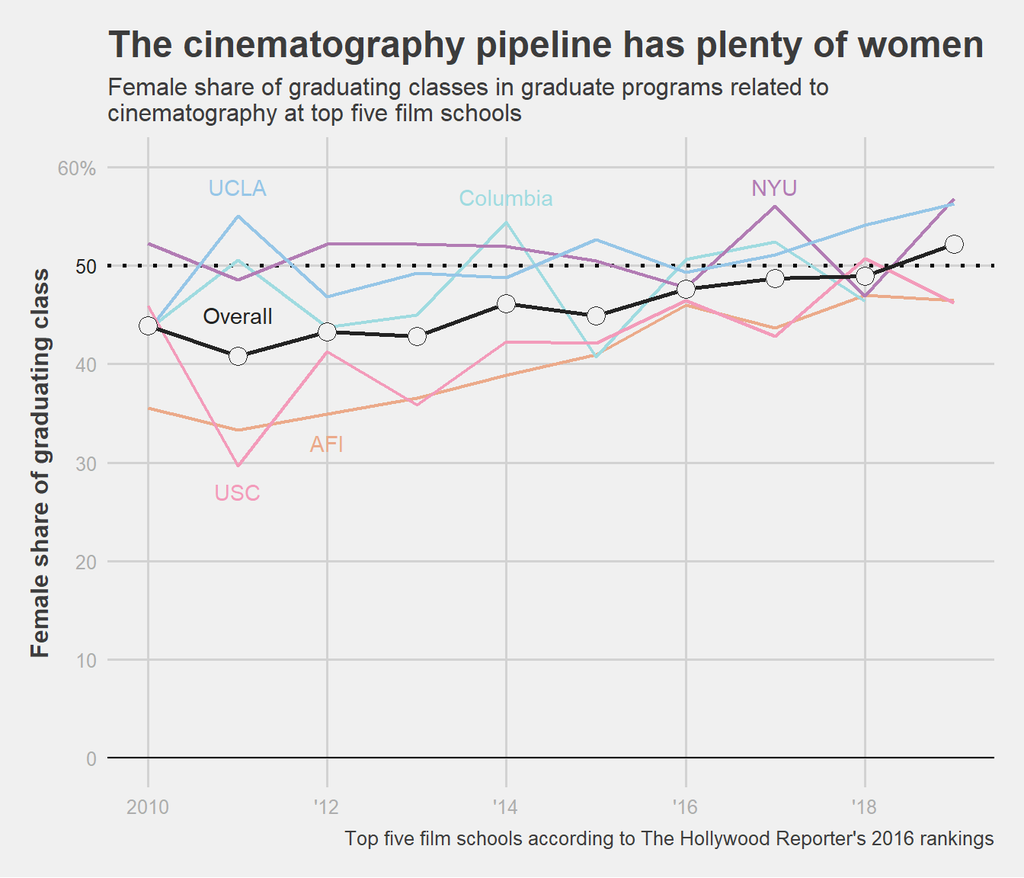

```r
df <- read_csv("https://github.com/ktoutloud/classslides/raw/master/math335/extra/women_film_data.csv") |>
  filter(awlevel == "07") |>
  mutate(school = case_when(
    school_id == 108870 ~ "AFI",
    school_id == 110662 ~ "UCLA",
    school_id == 123961 ~ "USC",
    school_id == 190150 ~ "Columbia",
    school_id == 193900 ~ "NYU"
  )) |>
  group_by(sex, school, year) |>
  summarise(
    count = sum(graduates)
  ) |>
  pivot_wider(names_from = sex, values_from = count) |>
  mutate(
    perc_female = female / (male + female) * 100
  )

overall <- df |>
  group_by(year) |>
  summarise(
    perc_female = sum(female) / (sum(male) + sum(female)) * 100
  ) |>
  mutate(school = "Overall")

namelabels <- data.frame(
  school = c("AFI", "UCLA", "USC", "Columbia", "NYU", "Overall"),
  year   = c(2012,  2011,   2011,   2014     , 2017,  2011),
  perc_female = c(32, 58, 27, 57, 58, 45)
)

ggplot(df, aes(x=year, y=perc_female, group=school, color=school)) +
  geom_hline(yintercept=50, linetype='dotted', size=1, show.legend=F) +
  geom_line(size=0.8, show.legend=F) +
  geom_line(data=overall, size=1, show.legend=F) +
  geom_point(data=overall,
             shape=21,
             fill="#F0F0F0",
             color='#232323',
             size=4,
             show.legend=F) +
  geom_text(data=namelabels, aes(label=school), show.legend=F) +
  geom_hline(yintercept=0, size=0.4) +
  scale_color_manual(values = c('AFI' = "#EBAA8A",
                                'UCLA' = "#96C6E7",
                                'USC' = "#F39BBA",
                                'Columbia' = "#9FDBE0",
                                'NYU' = "#B27CB4",
                                'Overall' = '#232323')) +
  scale_y_continuous(limits=c(0,60),
                     breaks = seq(0, 60, 10),
                     labels = c("0", "10", "20", "30", "40", "50", "60%")) +
  scale_x_continuous(breaks = seq(2010, 2018, 2),
                     labels = c("2010", "'12", "'14", "'16", "'18")) +
  labs(
    title="The cinematography pipeline has plenty of women",
    subtitle="Female share of graduating classes in graduate programs related to\ncinematography at top five film schools",
    y="Female share of graduating class",
    caption="Top five film schools according to The Hollywood Reporter's 2016 rankings"
  ) +
  ggthemes::theme_fivethirtyeight() +
  theme(
    axis.title.y = element_text(face="bold"),
    axis.text = element_text(color="#ADADAD"),
    axis.text.y = element_text(color=c('#ADADAD', '#ADADAD', '#ADADAD', '#ADADAD', '#ADADAD', '#232323', '#ADADAD'))
  )
```

[The Original](https://fivethirtyeight.com/wp-content/uploads/2018/03/hickey-cinematography-1.png):

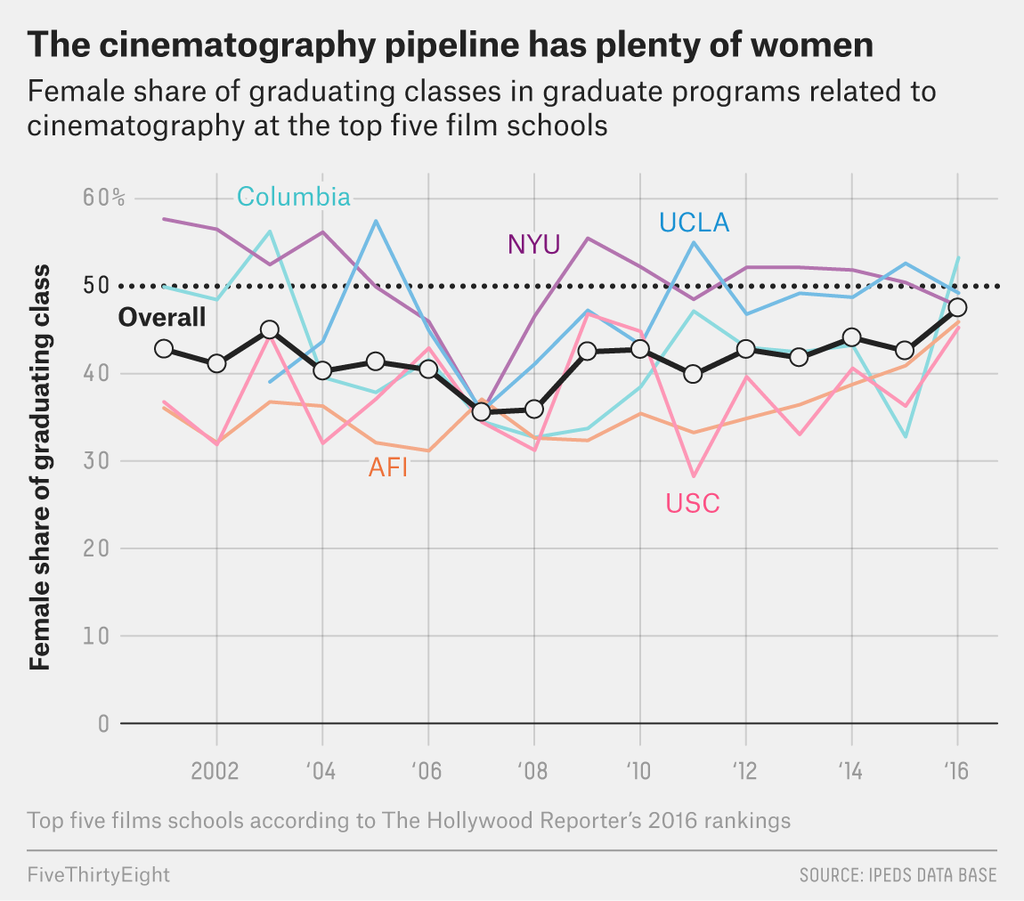

The data used for the recreation was slightly different, hence the difference in years on the x-axis.

##### Our World In Data

Recreating a visualization from **[Our World in Data](https://ourworldindata.org/grapher/fruit-consumption-vs-gdp-per-capita?time=latest)**

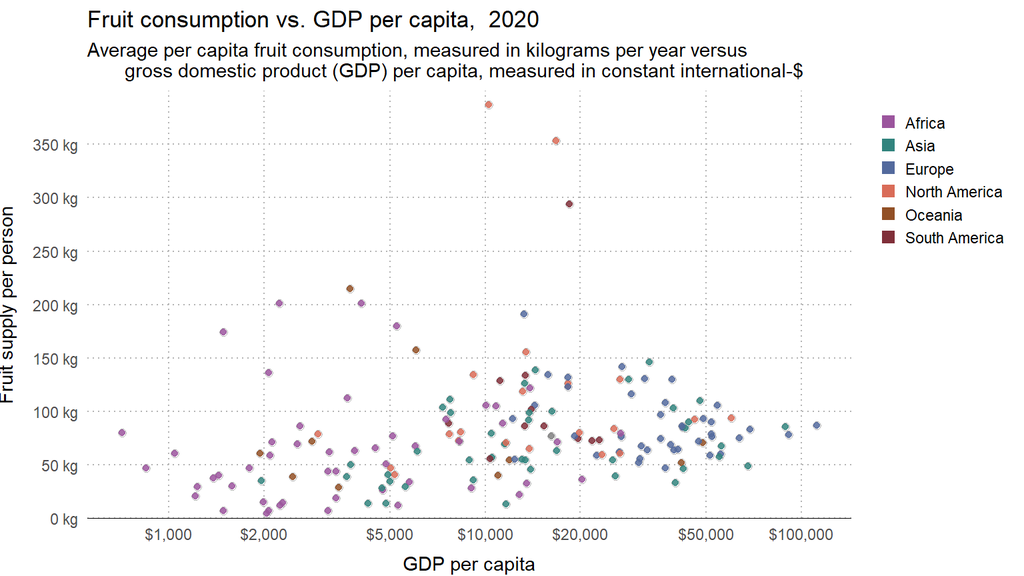

```r
fruit <- read_csv("DataWranglingAndVisualization/Mimic/fruit.csv")
colnames(fruit) <- c('Entity', 'Code', 'Year', 'Fruit', 'GDP', 'Continent')

continent <- fruit %>%
  filter(!is.na(Code)) %>%
  group_by(Entity) %>%
  fill(Continent, .direction='downup') %>%
  ungroup()

year <- continent %>%
  filter(Year == 2020)

country5 <- year %>%
  filter(Entity %in% c('Dominica',
                       'Dominican Republic',
                       'Guyana',
                       'Albania',
                       'Papua New Guinea',
                       'Ghana'))

ggplot(year, aes(x=GDP, y=Fruit, color=Continent)) +
  geom_point(size=2, shape=1, color='gray70') +
  geom_point(alpha=0.85) +
  scale_x_continuous(trans='log',
                     breaks=c(1000, 2000, 5000, 10000, 20000, 50000, 100000),
                     labels=c("$1,000", "$2,000", "$5,000", "$10,000", "$20,000", "$50,000", "$100,000")) +
  scale_y_continuous(limits = c(0,400),
                     expand = c(0,0),
                     breaks=seq(0, 350, 50),
                     labels=c('0 kg', '50 kg', '100 kg',
                              '150 kg', '200 kg', '250 kg',
                              '300 kg', '350 kg')) +
  scale_color_manual(values = c('Africa' = "#9B559D",
                                'Asia' = "#32847E",
                                'Europe' = "#536A9D",
                                'North America' = "#D96C58",
                                'Oceania' = "#925026",
                                'South America' = "#802F39"))+
  guides(color = guide_legend(override.aes = list(shape=15, alpha=1,size=3),
                              keyheight = 0.9,
                              keywidth = 0)) +
  labs(title="Fruit consumption vs. GDP per capita,  2020",
       subtitle="Average per capita fruit consumption, measured in kilograms per year versus
       gross domestic product (GDP) per capita, measured in constant international-$",
       x="GDP per capita",
       y="Fruit supply per person") +
  theme_classic() +
  theme(
    panel.grid.major = element_line(linetype='dotted', color='gray70'),
    axis.line.y = element_blank(),
    axis.line.x = element_line(size=0.25),
    axis.ticks.y = element_blank(),
    axis.ticks.x = element_blank(),
    legend.title = element_blank(),
    legend.justification = c(1,1),
    axis.title.x = element_text(vjust=-1),
    axis.title.y = element_text(vjust=4)
  )
```

Original Graph:

[figure not shown]

## Pandas, Seaborn and Altair (Python)

Pandas is used for data wrangling, while Seaborn and Altair are both Python Visualization libraries.

### *Which airport is best?*

“Delay Rating” is the porportion of flights which are delayed multiplied by the average hours of delay

```python
flights = pd.read_json("https://github.com/byuidatascience/data4missing/raw/master/data-raw/flights_missing/flights_missing.json")

# WRANGLING - PANDAS

# Gets rid of characters and just leaves numbers
flights['num_of_delays_carrier'] = (
    flights['num_of_delays_carrier'].str.replace(r'\D', '', regex=True)
)
# Replaces blank strings, -999, and "n/a" with the actual NaN value
flights = (flights
    .replace(["", -999, "n/a"], np.nan)
    .replace(["Febuary"], "February")
)
# Fills NaN values in num_of_delays_late_aircraft with the mean of the column
mean_late_air = flights.num_of_delays_late_aircraft.mean()
flights.num_of_delays_late_aircraft.fillna(mean_late_air, inplace=True)
# Fills NaN values with the month before them
flights.month.ffill(inplace=True)


totals = (flights
 .groupby("airport_code")
 .agg(
     total_minutes_delayed =
     ("minutes_delayed_total", np.sum),
     total_delays =
     ("num_of_delays_total", np.sum),
     total_flights =
     ("num_of_flights_total", np.sum),
).assign(
    total_hrs_delayed = lambda df: df.total_minutes_delayed / 60,
    ave_hrs_delayed = lambda df: df.total_hrs_delayed / df.total_delays,
    proportion_delayed = lambda df: df.total_delays / df.total_flights,
    delay_rating = lambda df: df.proportion_delayed * df.ave_hrs_delayed
).sort_values('delay_rating', ascending=False)
.reset_index()
)

# VISUALIZATION - ALTAIR
best_airport = alt.Chart(totals,
                         title= alt.Title(
                             "Airports Rated by Delay",
                             subtitle= "The higher the rating, the worse airport")).encode(
    x = alt.X('delay_rating:Q', title="Delay Rating"),
    y= alt.Y('airport_code:N', title="Airport Code", sort="-x"),
    color=alt.Color('airport_code:N', legend=None).scale(scheme="tealblues")
).mark_bar()
best_airport.save("Python/best_airport.html",embed_options={'width': 400})
```

[interactive chart not shown]

# 2. Statistical Analysis

## Linear Regression

#### *When should I sell my Honda Accord?*

Or, which Honda Accord should I buy? The “Buying Point” represents a Honda Accord for sale on [KSL](https://cars.ksl.com/) which, if bought and sold when reaching 75,000 miles, would allow you to drive it for 39,761 miles and gain $\approx 2$ cents per mile on its selling price. For more info …click here to see the full analysis

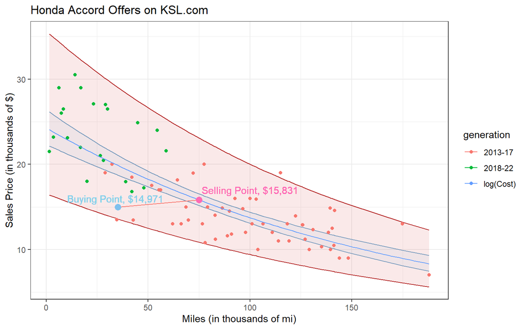

```r
car_raw <- read_csv('LinearRegression/CarSellingPrice/Honda_Accord_Sales_Data.csv')
car <- car_raw |>
  mutate(
    Year = as.factor(Year),
    generation = case_when(
      Year %in% c(2013,2014,2015,2016,2017) ~ '2013-17',
      TRUE ~ '2018-22'
    ),
    Miles = Miles / 1000,
    Cost = Cost / 1000
  )

car.lm <- lm(log(Cost)~Miles, data=car)
b <- coef(car.lm)
mylm <- lm(Cost~Miles, data=car)
confintv <- exp(predict(car.lm, interval="confidence"))
predintv <- exp(predict(car.lm, interval="prediction"))

buy_point <- data.frame(Miles=35.239, Cost=14.971, generation='2013-17')
sell_point <- data.frame(Miles=75, Cost=15.83134, generation='2013-17')

ggplot(car, aes(x=Miles, y=Cost, color=generation)) +
  geom_ribbon(aes(ymin=confintv[,2], ymax=confintv[,3]),
              alpha=0.1, fill='skyblue', color='skyblue3') +
  geom_ribbon(aes(ymin=predintv[,2], ymax=predintv[,3]),
              alpha=0.1, fill='firebrick3', color='firebrick') +
  geom_point() +
  geom_text(aes(label='Selling Point, $15,831'),
            x=100, y=17, color='hotpink') +
  geom_text(aes(label='Buying Point, $14,971'),
            x=34, y=16, color='skyblue') +
  geom_segment(data=buy_point, xend=75, yend=15.83134) +
  geom_point(data=buy_point, size=3, color='skyblue2', ) +
  stat_function(fun=function(x) exp(b[1]+b[2]*x), aes(color='log(Cost)')) +
  geom_point(data=sell_point, size=3, color='hotpink') +
  theme_bw() +
  labs(
    title="Honda Accord Offers on KSL.com",
    y="Sales Price (in thousands of $)",
    x="Miles (in thousands of mi)"
  )
```

## Multiple Linear Regression

#### *What effects a house’s price the most?*

This section only includes the information about the regression model. For further insights on which features of a house have the greatest impact on its price, refer to the “Interpreting the Model” section of the complete analysis.

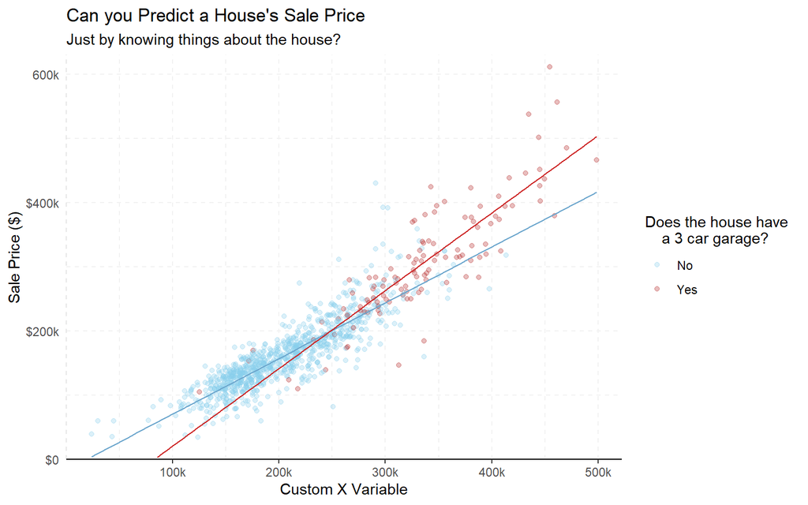

```r
houses <- read.csv("LinearRegression/MultipleLR/train.csv", header=T, stringsAsFactors = T)

# NA fill "No ____"
correctNAlist <- c("Alley", "Fence", "PoolQC", "FireplaceQu",
                   "MiscFeature", "GarageQual",
                   "GarageCond","GarageFinish", "GarageType",
                   "BsmtQual", "BsmtCond", "BsmtExposure", "BsmtFinType1",
                   "BsmtFinType2", "MasVnrType")
for (item in correctNAlist) {
  houses <- houses |>
    mutate(
      !!item := as.character(!!sym(item)),
      !!item := replace_na(!!sym(item), paste("No_", item)),
      !!item := as.factor(!!sym(item))
    )
}

# NA fill 0
fill_0 <- c("LotFrontage", "MasVnrArea")
for (item in fill_0) {
  houses <- houses |>
    mutate(
      !!item := replace_na(!!sym(item), 0)
    )
}

houses <- houses |>
  mutate(
    Electrical = replace_na(Electrical, "SBrkr"),
    GarageYrBlt = ifelse(GarageQual == "No_ GarageQual", 0, GarageYrBlt),
    TotalSF = TotalBsmtSF + X1stFlrSF + X2ndFlrSF,
    TotalSF = ifelse(TotalSF > 6000, mean(TotalSF), TotalSF),
    PercBsmtFin = (TotalBsmtSF - BsmtUnfSF) / BsmtUnfSF,
    PercBsmtFin = ifelse(is.na(PercBsmtFin) |
                           PercBsmtFin=="Inf", 0, PercBsmtFin),
    Has2nd = ifelse(X2ndFlrSF == 0, 1, 0),
    Has2nd = as.factor(Has2nd),
    HasBsmt = ifelse(TotalBsmtSF == 0, 1, 0),
    HasBsmt = as.factor(HasBsmt),
    BsmtExcellent = ifelse(BsmtQual == "Ex", 1, 0),
    GarageCar3 = ifelse(GarageCars == 3, 1, 0),
    #### BOOLEAN ####
      # 2nd Floor
    X2ndFlr = ifelse(X2ndFlrSF > 0, 1, 0),
    RichNeigh = case_when(
      Neighborhood %in% c("StoneBr","NridgHt","NoRidge") ~ 18.6342,
      Neighborhood %in% c("Blmngtn", "ClearCr", "CollgCr",
                          "Crawfor", "Gilbert", "NWAmes",
                          "SawyerW", "Somerst", "Timber", "Veenker") ~ 13.2532,
      T ~ 7.3327
    ),
    KitchenQ = case_when(
      KitchenQual == "Ex" ~ 3.28555,
      KitchenQual == "Gd" ~ -1.16439,
      KitchenQual == "TA" ~ -1.88592,
      KitchenQual == "Fa" ~ -2.22990,
    ),
    OverallQ = case_when(
      OverallQual == 1 ~ 0.4709,
      OverallQual == 2 ~ -5.5332,
      OverallQual == 3 ~ 18.5539,
      OverallQual == 4 ~ 28.4397,
      OverallQual == 5 ~ 34.9930,
      OverallQual == 6 ~ 43.1099,
      OverallQual == 7 ~ 53.9437,
      OverallQual == 8 ~ 65.5431,
      OverallQual == 9 ~ 82.3895,
      OverallQual == 10 ~ 93.5527
    ),
    customX = 42.872*(TotalSF) +
      9658.661*(KitchenQ) +
      1759.385*(OverallQ) +
      4113.104*(RichNeigh),
    megaSwitch = ifelse(MSZoning %in% c("RL", "FV", "RH"), 1, 0)
  )

set.seed(122)

num_rows <- 1000 #1460 total
keep <- sample(1:nrow(houses), num_rows)

train <- houses[keep, ] #Use this in the lm(..., data=mytrain)

test <- houses[-keep, ] #Use this in the predict(..., newdata=mytest)

final.lm <- lm(SalePrice~customX + customX:GarageCar3 + GarageCar3,data=train)

b <- coef(final.lm)

ggplot(train, aes(x=customX, y=SalePrice, color=as.factor(GarageCar3))) +
  geom_point(alpha=0.3) +
  scale_y_continuous(expand=c(0,0), limits = c(0, 630000), labels=c("$0", "$200k", "$400k", "600k")) +
  scale_x_continuous(labels=c("0", "100k", "200k", "300k", "400k", "500k")) +
  scale_color_manual(values = c("skyblue", "firebrick"), labels = c("No", "Yes")) +
  stat_function(fun=function(x) b[1] + b[2]*x, color="skyblue3") +
  stat_function(fun=function(x) (b[1] + b[3]) + (b[2] + b[4])*x, color="firebrick3") +
  labs(title="Can you Predict a House's Sale Price",
       subtitle="Just by knowing things about the house?",
       x="Custom X Variable",
       y="Sale Price ($)",
       color="Does the house have \n    a 3 car garage?") +
  theme_classic() +
  theme(
    panel.grid.major = element_line(color='gray95', linetype='dashed'),
    panel.grid.minor = element_line(color='gray95', linetype='dashed'),
    axis.line.y = element_line(color='gray90', linetype='dashed'),
    axis.ticks.y = element_blank()
  )
```

Here is the summary of the multiple linear regression:

```r
summary(final.lm) |>
  pander()
```

|  | Estimate | Std. Error | t value | Pr(>\|t\|) |
| --- | --- | --- | --- | --- |
| **(Intercept)** | -15975 | 3923 | -4.072 | 5.03e-05 |
| **customX** | 0.8676 | 0.01851 | 46.87 | 3.57e-254 |
| **GarageCar3** | -84158 | 14575 | -5.774 | 1.034e-08 |
| **customX:GarageCar3** | 0.3429 | 0.04518 | 7.591 | 7.303e-14 |

Fitting linear model: SalePrice ~ customX + customX:GarageCar3 + GarageCar3

| Observations | Residual Std. Error | $R^2$ | Adjusted $R^2$ |
| --- | --- | --- | --- |
| 1000 | 29537 | 0.8463 | 0.8458 |

After running the model on a validation set of data, the Adjusted R-squared only dropped by 0.04, showing that this model does work well at predicting new data. It should be noted that this model can predict within $60k of the actual sales price 95% of the time.

```r
y <- predict(final.lm, newdata=test)

ybar <- mean(test$SalePrice)

SSTO <- sum( (test$SalePrice - ybar)^2 )

# Compute SSE for each model using SalePrice - yhat
SSE <- sum( (test$SalePrice - y)^2 )

# Compute R-squared for each
rs <- 1 - SSE/SSTO


n <- length(test$SalePrice) #sample siz
p <- length(coef(final.lm))
rsa <- 1 - (n-1)/(n-p)*SSE/SSTO

my_output_table2 <- data.frame(Model = c("MyLM"), `Original R2` = c(summary(final.lm)$r.squared), `Orig. Adj. R-squared` = c(summary(final.lm)$adj.r.squared), `Validation R-squared` = c(rs), `Validation Adj. R^2` = c(rsa))

colnames(my_output_table2) <- c("Model", "Original $R^2$", "Original Adj. $R^2$", "Validation $R^2$", "Validation Adj. $R^2$")

knitr::kable(my_output_table2, escape=TRUE, digits=4)
```

| Model | Original $R^2$ | Original Adj. $R^2$ | Validation $R^2$ | Validation Adj. $R^2$ |
| --- | --- | --- | --- | --- |
| MyLM | 0.8463 | 0.8458 | 0.804 | 0.8027 |

## Other Statistical Methods

#### T Test

##### *Do Men play video games more than Women?*

…click here for full analysis

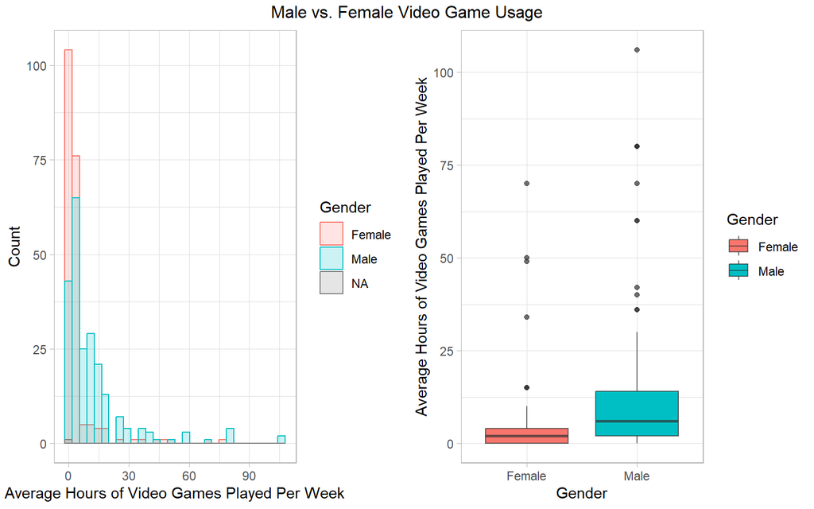

```r
HSS <- read_csv("Analyses/TTest/HighSchoolSeniors.csv")
hist <- ggplot(HSS) +
  geom_histogram(
    aes(x=Video_Games_Hours,
        fill= Gender,
        color= Gender),
    alpha=0.2,
    position='identity'
    ) +
  theme_light() +
  labs(x="Average Hours of Video Games Played Per Week",
       y="Count")
box <- HSS |>
  drop_na() |>
ggplot(aes(y=Video_Games_Hours, x=Gender)) +
  geom_boxplot(aes(fill=Gender), color=rgb(0.2,0.2,0.2,0.7)) +
  theme_light() +
  labs(x="Gender",
       y="Average Hours of Video Games Played Per Week")
gridExtra::grid.arrange(hist, box, ncol=2, top = grid::textGrob("Male vs. Female Video Game Usage"))
```

```r
t_test <- t.test(Video_Games_Hours ~ Gender, data=HSS, alternative="less") |>
  pander()
```

#### ANOVA

##### *Does Music and/or Laptop Position affect Typing Speed?*

For more details, view analysis

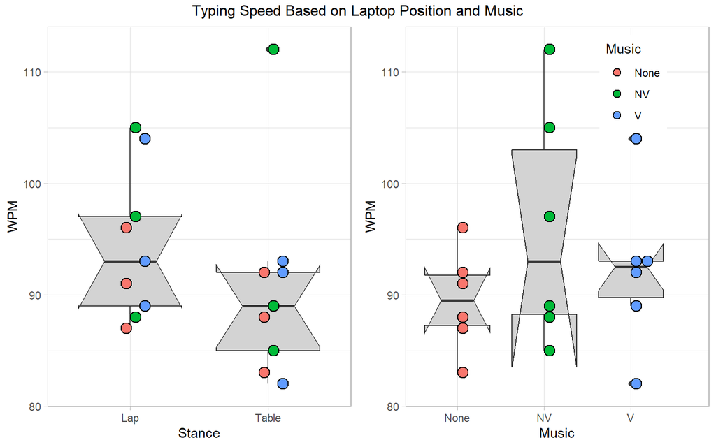

```r
typeSpeed <- read_csv("Analyses/ANOVA/type_data.csv")
stance <- ggplot(typeSpeed, aes(x= Stance, y= WPM)) +
  geom_boxplot(fill='lightgray', notch=TRUE) +
  geom_dotplot(aes(fill= Music), binaxis= 'y', stackdir= 'up',
               position=position_dodge(0.2),
               show.legend=F) +
  theme_light()
music <- ggplot(typeSpeed, aes(x= Music, y= WPM, fill= Music)) +
  geom_boxplot(fill='lightgray', notch=TRUE) +
  geom_dotplot(binaxis= 'y', stackdir= 'up',
               position=position_dodge(0.2)) +
  theme_light() +
  theme(legend.position=c(0.75,0.85))
gridExtra::grid.arrange(stance, music,
                       ncol=2,
                       top=grid::textGrob("Typing Speed Based on Laptop Position and Music"))
```

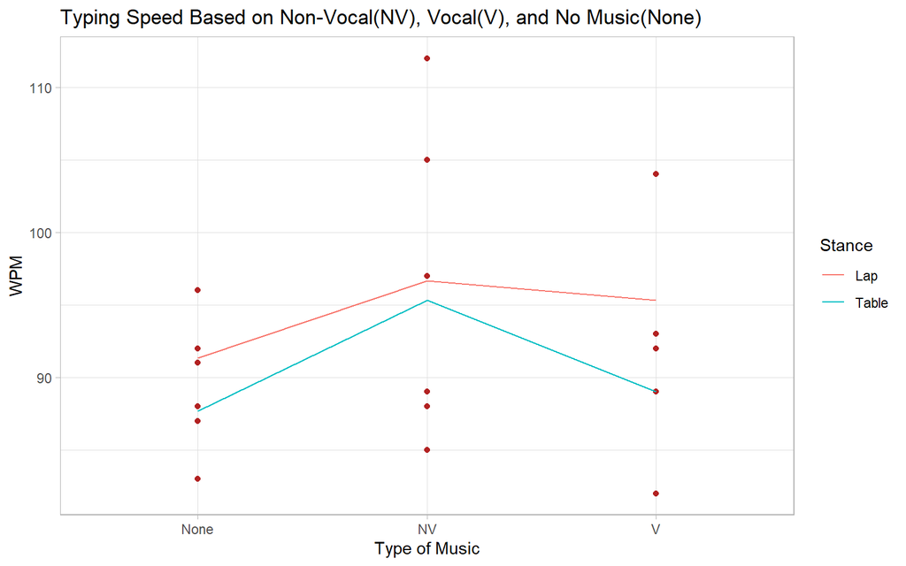

```r
ggplot(typeSpeed, aes(x=Music, y=WPM, group=Stance, color=Stance)) +
  geom_point(color='firebrick') +
  stat_summary(fun='mean', geom='line') +
  labs(title="Typing Speed Based on Non-Vocal(NV), Vocal(V), and No Music(None)",
       y="WPM",
       x="Type of Music") +
  theme_light()
```

```r
typeSpeed.aov <- aov(WPM ~ Music + Stance + Music:Stance, data=typeSpeed)
summary(typeSpeed.aov) %>%
  pander()
```

Analysis of Variance Model

|  | Df | Sum Sq | Mean Sq | F value | Pr(>F) |
| --- | --- | --- | --- | --- | --- |
| **Music** | 2 | 128.1 | 64.06 | 0.9093 | 0.4288 |
| **Stance** | 1 | 64.22 | 64.22 | 0.9117 | 0.3585 |
| **Music:Stance** | 2 | 18.78 | 9.389 | 0.1333 | 0.8765 |
| **Residuals** | 12 | 845.3 | 70.44 | NA | NA |

#### Wilcoxon Test

##### *What learning method leads to the best outcomes?*

3 learning methods were attempted in a recalling words test.The following graphic represents the distribution of the test results from each group.

For more results / interpretation: see the full analysis

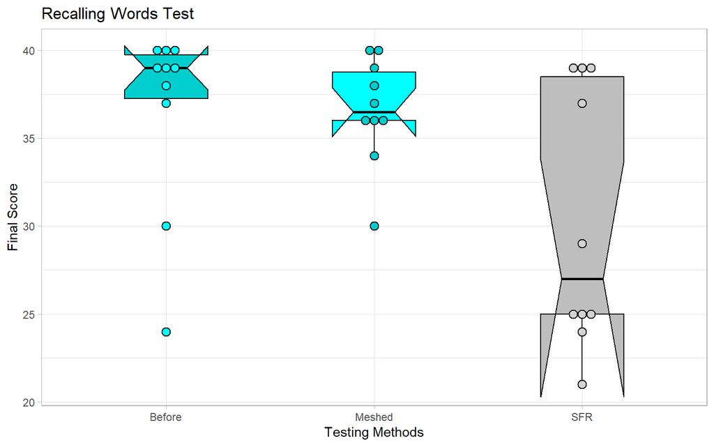

```r
ggplot(Friendly, aes(
  x= condition,
  y= correct,
  fill= condition)) +
  geom_boxplot(fill= c('cyan3', 'cyan', 'gray'), color= 'black',
               notch=TRUE, width= 0.4) +
  geom_dotplot(binaxis= 'y', position= 'dodge', stackdir='center',
               binwidth = 0.5) +
  scale_fill_manual(values=c("cyan", "cyan3", "lightgray")) +
  labs(title="Recalling Words Test",
       x= "Testing Methods",
       y= "Final Score") +
  theme_light() +
  theme(legend.position= 'none')
```

```r
wilcox.test(Friendly$correct[Friendly$condition == 'Meshed'], Friendly$correct[Friendly$condition == 'Before']) %>%
  pander(caption="Wilcoxon rank some test with continuity correction (there are ties in the data)")
```

Wilcoxon rank some test with continuity correction (there are ties in the data)

| Test statistic | P value | Alternative hypothesis |
| --- | --- | --- |
| 38 | 0.378 | two.sided |

Conclusion: The “Before” or “Meshed” learning approaches should be used over the “SFR” method.

#### Logistic Regression

##### *Can you predict happiness?*

Using data from the GSS (General Social Survey), I created a model which predicted whether or not someone was happy based on a Happiness rating, which I derived from 11 of the survey questions involving physical and mental health, social relations, education, and religion. In the analysis, I also ran a RandomForest ML model to predict one’s happiness based on their survey answers with an 83% accuracy.

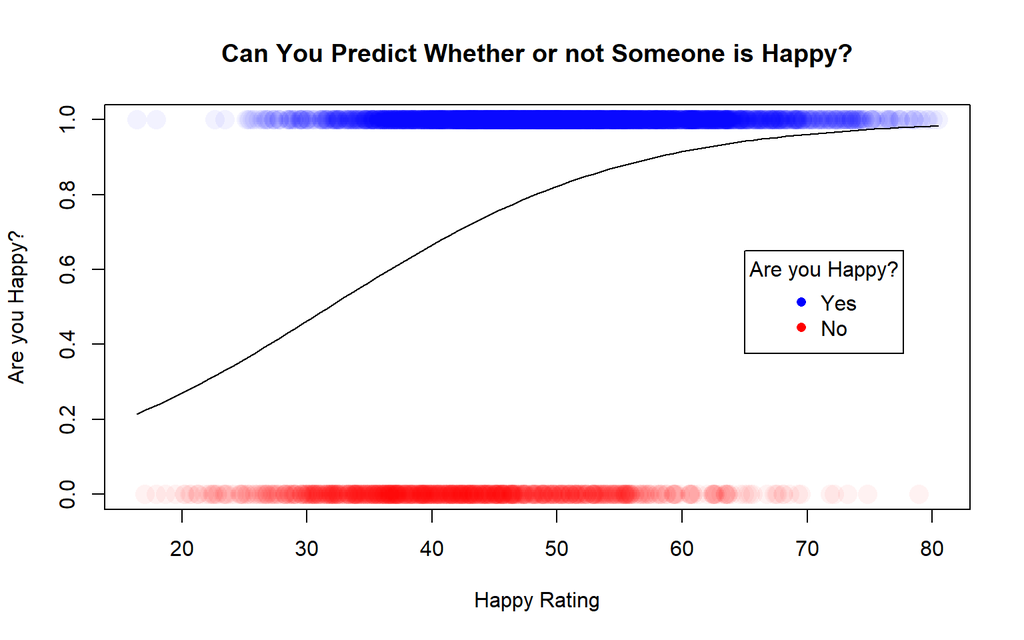

```r
gss2021 <- read_sas("Analyses/LogisticRegression/gss2021.sas7bdat",
    NULL)

# Filter Data and Create Happy_Rating
mygss <- gss2021 %>%
  select(c('HAPPY', 'HAPMAR','LIFE', 'SATSOC', 'HLTHMNTL', 'ACTSSOC', 'HEALTH', 'EMOPROBS', 'ATTEND', 'EDUC', 'RELACTIV', 'HLTHPHYS')) %>%
  filter(!is.na(HAPPY)) %>% # Drop NA rows in the "HAPPY" column
  mutate( # Merge "Pretty Happy" and "Very Happy" columns to just be "Happy" ~ 1
    HAPPY = case_when(
      HAPPY %in% c(1,2) ~ 1,
      HAPPY %in% 3 ~ 0
    )
  ) %>%
  mutate_all(~ifelse(is.na(.), mean(., na.rm = TRUE), .)) %>% # Fill NA with mean()
  mutate_all(~ . / max(.)) %>%  # Divide each column by its max value
  mutate( # Invert scale on questions that had inverse numbered answers
    ATTEND = ATTEND * -1 + 1,
    RELACTIV = RELACTIV * -1 + 1,
    EDUC = EDUC * -1 + 1,
  ) %>%
  mutate( # Scale each factor to match its importance in the ML
    Happy_Rating = -100 * (EDUC * 0.15426218 +
                   ATTEND * 0.12488643 +
                   HAPMAR * 0.11542531 +
                   RELACTIV * 0.11377695 +
                   SATSOC * 0.08842675 +
                   EMOPROBS * 0.08201357 +
                   LIFE * 0.07298428 +
                   ACTSSOC * 0.06718067 +
                   HLTHMNTL * 0.06597608 +
                   HLTHPHYS * 0.06001798 +
                   HEALTH * 0.05504979) + 100,
    Happy_Rating_Unscaled = -10 * (EDUC +
                   ATTEND + HAPMAR +
                   RELACTIV + SATSOC +
                   EMOPROBS + LIFE +
                   ACTSSOC + HLTHMNTL +
                   HLTHPHYS + HEALTH) + 100
  )

# Run Logistic Regression
gss.glm <- glm(HAPPY ~ Happy_Rating, data = mygss, family=binomial)

# Graph Logistic Regression
palette(c(rgb(1,0,0, alpha =0.05),rgb(0,0,1, alpha =0.05)))
plot(HAPPY ~ Happy_Rating, data = mygss, col=as.factor(HAPPY), pch=16, cex=2, xlab = "Happy Rating", ylab = "Are you Happy?", main = "Can You Predict Whether or not Someone is Happy?")
b <- coef(gss.glm)
curve(exp(b[1] +b[2]*x)/(1+exp(b[1] +b[2]*x)), add=TRUE)
legend(x=65, y=0.65, legend = c("Yes", "No"), col = c('blue', 'red'), pch = 16, title = "Are you Happy?")
```

# 3. SQL

## Querying

### *Of all players with over 100 bats, who, of all baseball players, had the highest career batting average?*

Note: this table was generated in a python file in Visual Studio, and then copied over, due to the limitations of running python code in a RMD file along with other R code. However, the code used can still be seen by clicking “Show”

```python
import sqlite3

try:
  con = sqlite3.connect('lahmansbaseballdb.sqlite')

  batting_avg_career = pd.read_sql_query(
      """
      SELECT playerID, SUM(H), SUM(AB), 1.0*SUM(H) / SUM(AB) as Career_Batting_Avg
      FROM Batting
      GROUP BY playerID
      HAVING SUM(AB) >= 100
      ORDER BY Career_Batting_Avg DESC, playerID
      LIMIT 5
      """, con)
except:
  pass
```

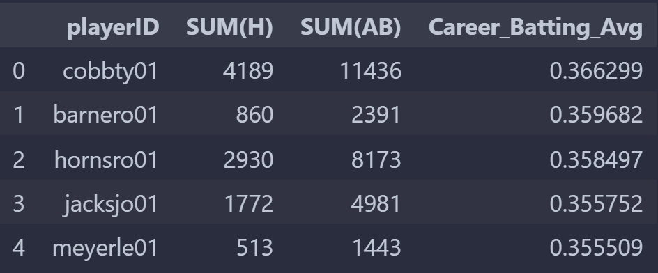

I am comfortable with SQL querying.

## Database Design

I am familiar with MySQL and database design. I have not yet experienced uploading the format to a server and fully implementing it, but I do understand the principles of good database design; below is a database I made replicating that of what [nitrotype](https://www.nitrotype.com/), an online type racing game, would use.

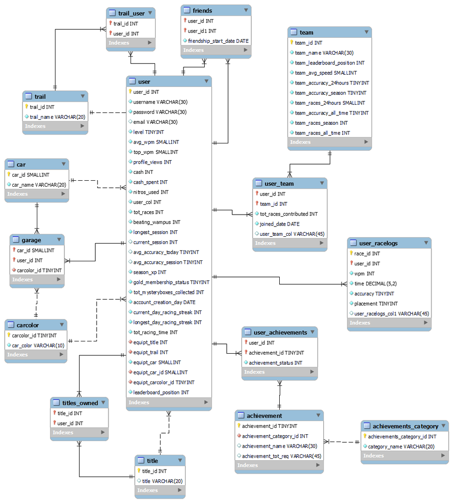

# 4. Machine Learning

All of my Machine Learning experience has been in Python using the Tensorflow-Keras library. I am comfortable with:

- Decision Trees
- Random Forest
- Gradient Boost
- XGBoost
- Neural Networks
  - Typical “Feed-Forward” Network
  - Convolutional Neural Network (CNN)
    - Image Classification
  - Recurrent Neural Network (RNN)
    - Text Generation

Here are some examples of my work

## NN

1-hour Coding Challenge: Create a ML model to classify rice species:

[See code in Colab Notebook](https://colab.research.google.com/drive/1h_1KrSXrqNJDyNljDeOCQannQRjNpQVD#scrollTo=yq9LpSdq82x4)

Within the hour, I was able to:

- Create some basic data exploration visualizations
- Compare and contrast an XGBoost model and Neural Network on the data.
- Refine the Neural Network to an F1-score of 0.944.

My model was within the top 5 of the class.

## CNN - Image Recognition

Trained a CNN to classify 43 different types of street signs in Germany. This model performed with 96% accuracy on a holdout set of images, never before seen by the model.

[See code in Colab Notebook](https://colab.research.google.com/drive/1XXTgQaqdupCjPVCkBbdycCjFRuf9zNAp#scrollTo=CVSfaqgKPzE2)